# pratikum_2 AK-281 ADW

Kevin Synagogue Panjaitan 10023481

2024-03-30

Model Tak Stasioner

Tujuan Pratikum

1. Menganalisis deret waktu dan memodelkannya
2. Memahami Langkah-langkah Iterasi box jenkins

# Jurnal 1

Data deret waktu yang baik adalah data yang memiliki ukuran setidaknya 50 observasi. Jika kurang dari 50 observasi, maka hasil pengolahan data deret waktu dapat menjadi sangat bias dan juga kita pelu memenuhi kelangkapan suatu data keandalan dan relvansi suatu data

ada beberapa skema alur pemodelan suatu data yaitu Analisis data atau (EDA) , Mempersiapkan data atau data prosesing, Indentifikasi suatu model kita tinjau autokorelasi dan autokorelasi parsialnya , estimasi parameter dimana kita mengecek suatu data apakah bias atau konsisten, Uji diagnostik dimana kita mengecek apakaha dia berdistribusi normal, saling bebas dan komoskedastis selanjutnya penaksiran atau forescasting dimana kita akan menggunkan iterasi Box-Jenkins

===============================================================================================================================================

# Eda (Studi kassus : data tanjung priok)

```r
library(readxl)
library(dplyr)
library(tidyr)
```

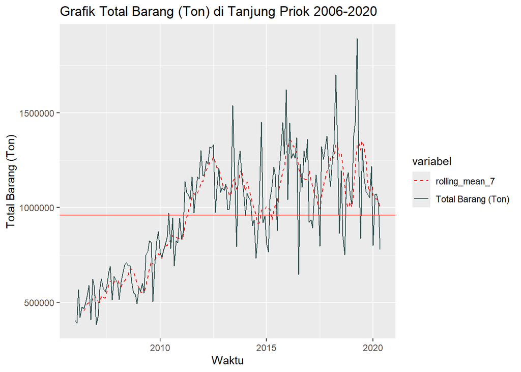

```r
library(ggplot2)
library(zoo)
library(tseries)
# Memanggil Data
#ganti data yang hilang
data <- read_excel("Data1.xlsx", sheet = "Tanjung Priok", col_types = c("date", "numeric"))

# Menghitung rolling mean 7 hari
data <- data %>%
  mutate(rolling_mean_7 = rollmean(`Total Barang (Ton)`, k = 6.5, fill = NA, align = "right"))

# Mengelompokkan data
df <- data %>%
  select(Waktu, `Total Barang (Ton)`, rolling_mean_7) %>%
  gather(key = "variabel", value = "value", -Waktu)

# Membuat grafik data
ggplot(df, aes(x = Waktu, y = value, group = variabel)) +
  geom_line(aes(linetype = variabel, color = variabel)) +
  geom_hline(yintercept = mean(data$`Total Barang (Ton)`), color = "brown1") +
  scale_linetype_manual(values = c("dashed", "solid", "dashed")) +
  scale_color_manual(values = c("red", "darkslategrey")) +
  labs(title = "Grafik Total Barang (Ton) di Tanjung Priok 2006-2020", x = "Waktu", y = "Total Barang (Ton)")
```

```r
# Statistik Deskriptif
summary(data)
```

```
##      Waktu                        Total Barang (Ton) rolling_mean_7
##  Min.   :2006-01-01 00:00:00.00   Min.   : 383471    Min.   : 453263
##  1st Qu.:2009-08-01 00:00:00.00   1st Qu.: 709685    1st Qu.: 737815
##  Median :2013-03-01 00:00:00.00   Median : 989212    Median :1042328
##  Mean   :2013-03-01 18:35:22.53   Mean   : 959191    Mean   : 967191
##  3rd Qu.:2016-10-01 00:00:00.00   3rd Qu.:1174929    3rd Qu.:1153315
##  Max.   :2020-05-01 00:00:00.00   Max.   :1894263    Max.   :1356669
##                                                      NA's   :5
```

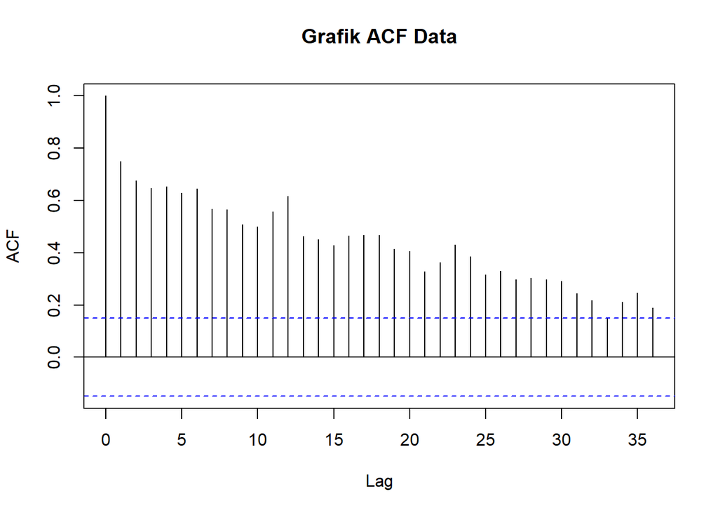

```r
#plot acf data

acf(data$`Total Barang (Ton)`, main = "Grafik ACF Data", lag.max = 36)
```

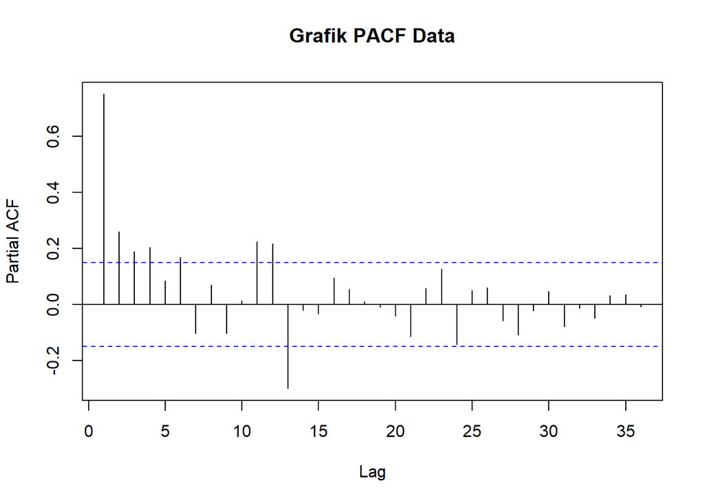

```r
#plot pacf data
pacf(data$`Total Barang (Ton)`, main = "Grafik PACF Data", lag.max = 36)
```

# Beberapa hal yang didapatkan

1.kualitas dan kelengkapan data kita pada kode summary(data) kita tau data tersebut lengkap dimana tertera mean dari sebuah data memiliki sebuah nilai yang tertera manandakan data tersebut lengkap dan siap di analisis lebih lanjut

4.pada interpretasi af seperti pola model ma(moving avarange) pada model tersebut plot acf akan cutt off pada lag-q dan pada plot pacf seperti mode autoregresif(ar) dia akan cut off setelah lag (p)

# Jurnal 2

langkah berikutnya data diolah dan kita akan memilih model yagn sedehana yang akan menjadi base model data tersebut.

# Mempersipakan data

```r
#mnegetahui jumlah data
# Mengetahui jumlah baris dan kolom dari data frame
dim_data <- dim(data)
jumlah_baris <- dim_data[1]
jumlah_kolom <- dim_data[2]

# Cetak jumlah baris dan kolom
print(paste("Jumlah baris:", jumlah_baris))
```

```
## [1] "Jumlah baris: 173"
```

```r
print(paste("Jumlah kolom:", jumlah_kolom))
```

```
## [1] "Jumlah kolom: 3"
```

```r
# Membuat data train dan validation dan mengubahnya menjadi data
# time series
# Ini dibutuhkan untuk menghasilkan data prediksi
tpriok <- ts(data$`Total Barang (Ton)`)
# data yang akan digunakan untuk membuat model
tpriok_train <- ts(data$`Total Barang (Ton)`, start = c(1), end = c(length(data$`Total Barang (Ton)`)))
# data yang akan digunakan untuk memvalidasi model
tpriok_test <-ts(data$`Total Barang (Ton)`, start = c(1), end = c(length(data$`Total Barang (Ton)`)))
```

#menghitung rmse train

```r
y_mean <- mean(tpriok_train)
rmse_train <- mean((tpriok_train - y_mean)^2)^0.5
rmse_train
```

```
## [1] 300122.8
```

# menghitung mape train

```r
y_mean <- mean(tpriok_train)
mape_train <- mean(abs((tpriok_train - y_mean))/tpriok_train)
mape_train
```

```
## [1] 0.3209963
```

#beberapa yang didapatkan

1.karena data kurang dari 3000 maka pengamatan tersebut tidak dapat menyelesaikan masalah pada model berikut dengan pengamatan 3000 kita dapat hasil yang rmse dan mape yang sama

2.kita dapat membagi data menjadi data pelatihan dan validasi dengan menggunakan persentase dari jumlah total data yang tersedia dalam dataset, maka untuk menghindari ketergantungan pada ukuran sampel kita dapat mencoba berbagai ukuran dataset yang di butuhkan .

3.Pemilihan rasio yang tepat tergantung pada karakteristik data, kompleksitas model, dan tujuan analisis. Rasio seperti 70:30, 50:50, atau bahkan 99:1 dapat dipertimbangkan tergantung pada kebutuhan spesifik analisis sebuah data.

# Jurnal 3

## Estimasi Parameter

```r
# Menghitung uji adf tpriok_train
uji_adf <- adf.test(tpriok_train)
uji_adf
```

```
##
##  Augmented Dickey-Fuller Test
##
## data:  tpriok_train
## Dickey-Fuller = -2.0344, Lag order = 5, p-value = 0.5619
## alternative hypothesis: stationary
```

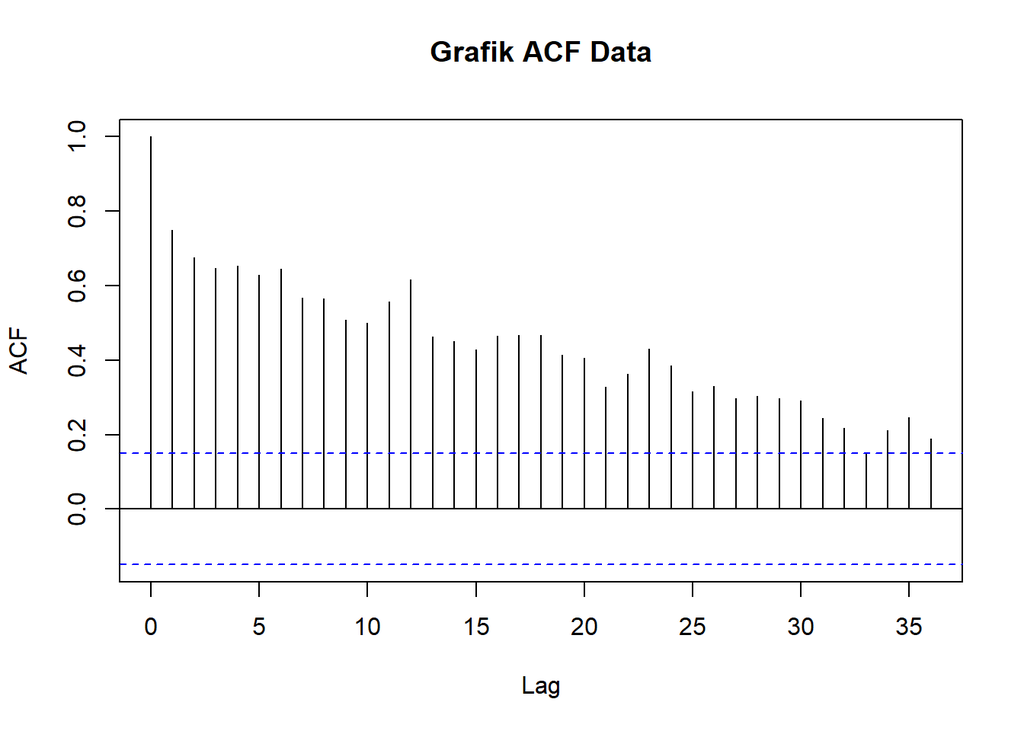

```r
# informasi uji adf
#cat("\nDickey-Fuller =", uji_adf$statistic, ", p-value =", uji_adf$p.value, "\nalternative hypothesis: stationary\n")

# Plot ACF data dengan lag maksimum 36
acf(tpriok_train, main = "Grafik ACF Data", lag.max = 36, cex.main = 1.5)
```

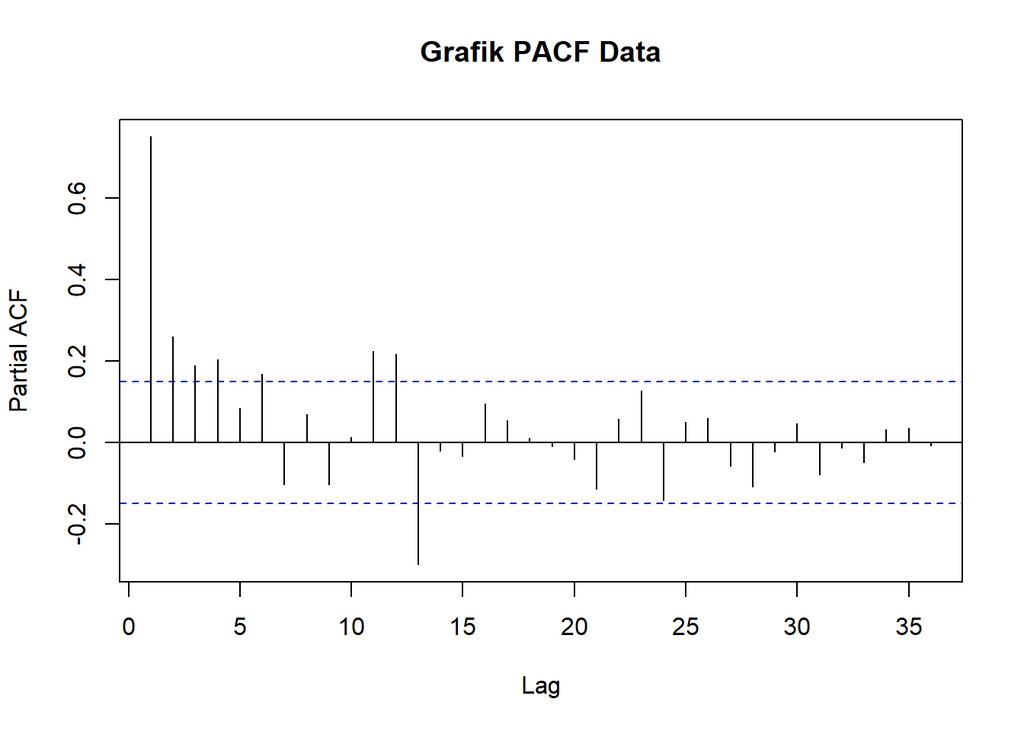

```r
pacf(tpriok_train, main = "Grafik PACF Data", lag.max = 36, cex.main = 1.5)
```

```r
tpriok_train_diff <- diff(tpriok_train)
#uji adf tpriok_train_diff

uji_adf_dif <- adf.test(tpriok_train_diff)
uji_adf_dif
```

```
##
##  Augmented Dickey-Fuller Test
##
## data:  tpriok_train_diff
## Dickey-Fuller = -7.2589, Lag order = 5, p-value = 0.01
## alternative hypothesis: stationary
```

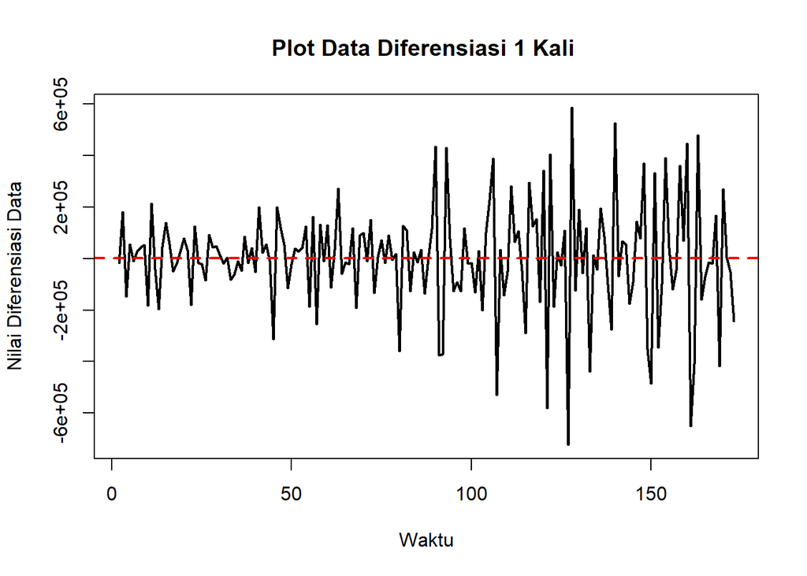

```r
plot(tpriok_train_diff, lwd = 2, main = "Plot Data Diferensiasi 1 Kali ",

xlab = "Waktu", ylab = "Nilai Diferensiasi Data")
abline(h = mean(tpriok_train_diff), lwd = 2, lty = 2, col = "red")
```

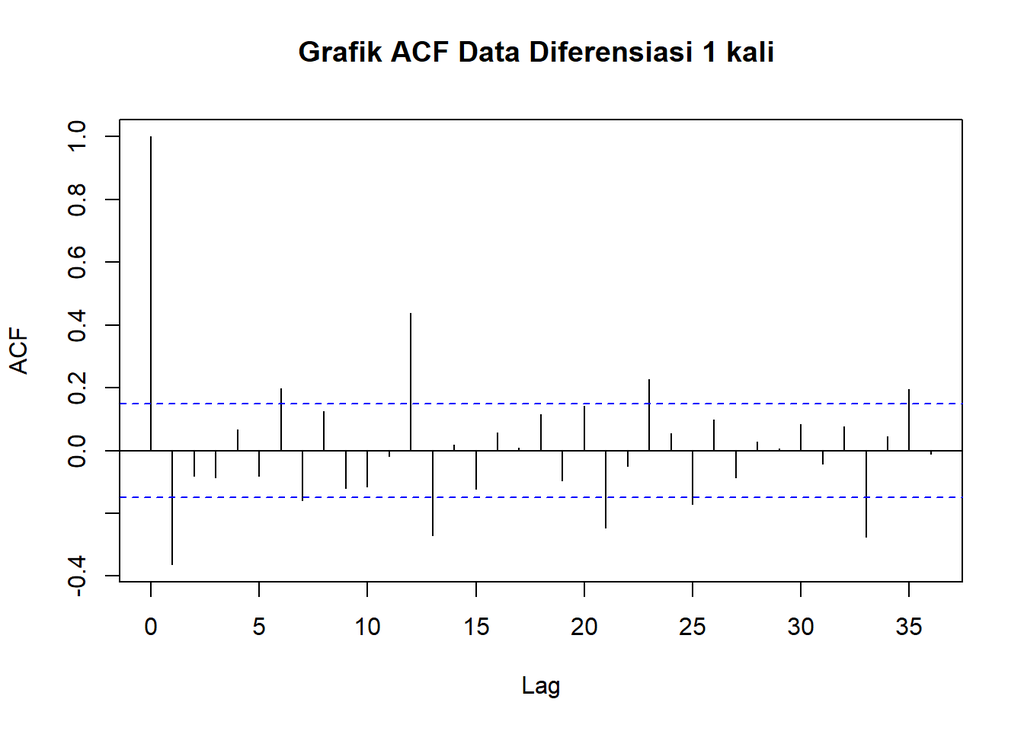

```r
acf(tpriok_train_diff, main = "Grafik ACF Data Diferensiasi 1 kali ", lag.max = 36)
```

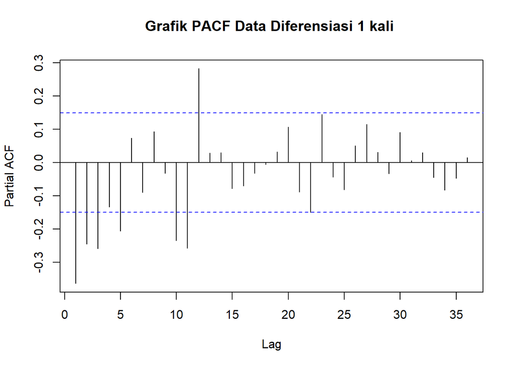

```r
pacf(tpriok_train_diff, main = "Grafik PACF Data Diferensiasi 1 kali ", lag.max = 36)
```

# hasil diffresialkan 2 kali

```r
tpriok_train_diff2 <- diff(tpriok_train_diff)
#uji adf tpriok_train_diff

uji_adf_dif2 <- adf.test(tpriok_train_diff2)
```

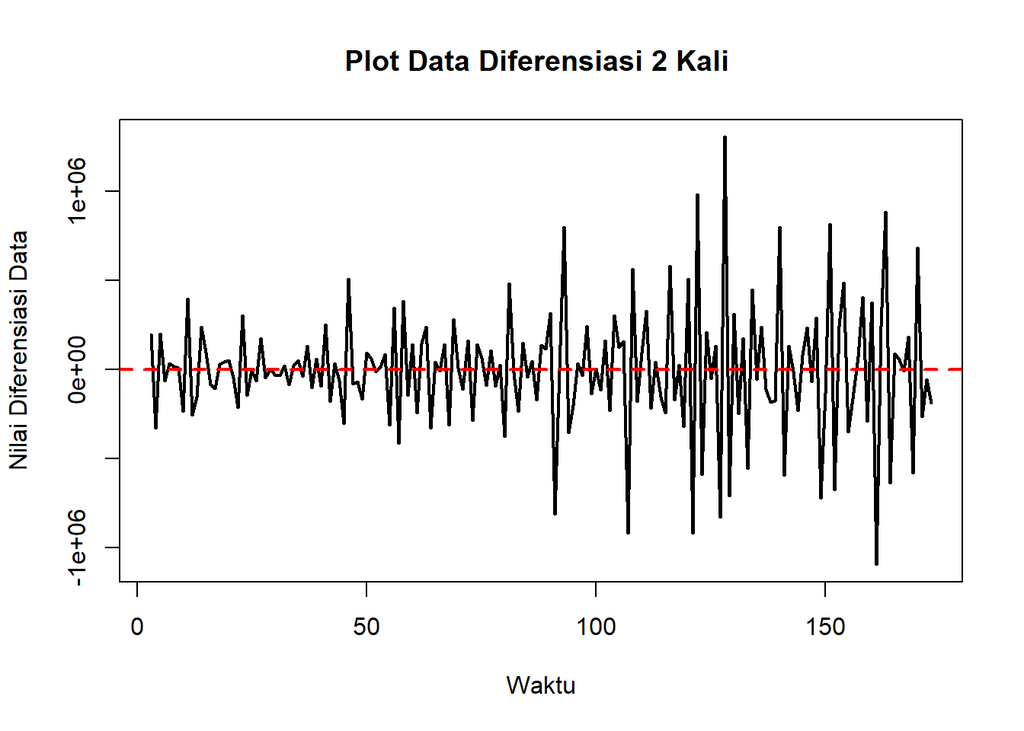

```r
plot(tpriok_train_diff2, lwd = 2, main = "Plot Data Diferensiasi 2 Kali ",

xlab = "Waktu", ylab = "Nilai Diferensiasi Data")
abline(h = mean(tpriok_train_diff2), lwd = 2, lty = 2, col = "red")
```

```r
cat("\nDickey-Fuller =", uji_adf_dif2$statistic, ", p-value =", uji_adf_dif2$p.value, "\nalternative hypothesis: stationary\n")
```

```
##
## Dickey-Fuller = -11.03262 , p-value = 0.01
## alternative hypothesis: stationary
```

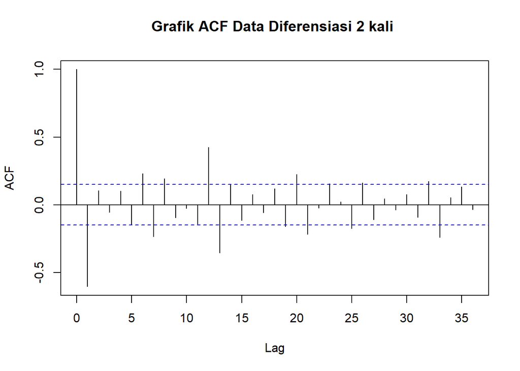

```r
acf(tpriok_train_diff2, main = "Grafik ACF Data Diferensiasi 2 kali ", lag.max = 36)
```

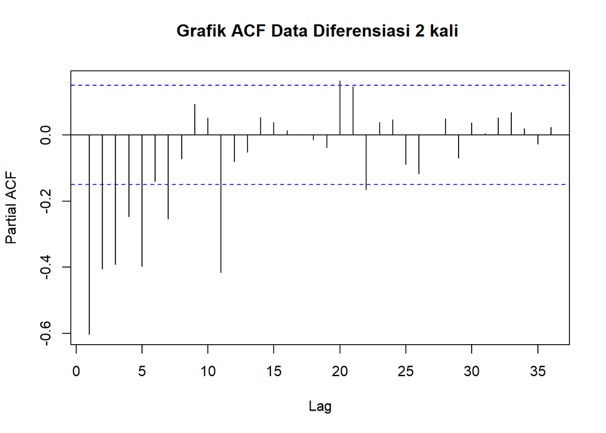

```r
pacf(tpriok_train_diff2, main = "Grafik ACF Data Diferensiasi 2 kali ", lag.max = 36)
```

# beberapa hal yang didapatkan

1.Beberapa hal yang didapat jika kita menggunakan metode diffrensialkan 1 kali dan 2 kali kita dapat memiliki sama mendapatkan model yang stasioner akan tetapi terdapat perbedaan yaitu nilai Dickey-Fuller yang berbeda sacara signifikan

2.mungkin yang lebih cocok yaitu metode diffrensial 2 kali karena memiliki nilai Dickey-Fuller yang sangat kecil

3.Tidak ada metode yang lebih baik karena disini kita hanya mengecek kestasioneran model yang di peroleh

# Jurnal 4

## Estimasi Parameter

Beberapa metode untuk untk mengestimasi parameter yaitu, metode kuadrat, metode maksimum likelihood dan metode momen,Metode kuadrat yaitu metode yang fokus pada memperkirakan parameter dalam suatu model yang paling sesuai dengan data yang diamati, kalu metode maksimum likelihood itu adalah metode yang menemukan nilai parameter yang paling mungkin menjelaskan data yang diamati, berdasarkan probabilitasnya dan memaksimalkan parameter fungsi yang akan diamati jika metode moment itu berfokus pada pencocokan distribusi fungsi parameter yang akan kita estimasi

dalam ketiga metode itu masing masing memiliki kekurangan dan kelebihan jika metode kuadrat memiliki kelebihan yaitu implementasi mudah digunakan dan mudah di pahami kekurangannya yaitu kita sulit menemukan hasil yang optimal jika maksimum likelihood itu sulit dipahami dan metode lebih rumuit akan tetapi hasil nya lebih optimal dan jika metode moment itu memberikan estimasi parameter yang efisien dan konsisten akan tetapi kita sulit menentukan distribusi data yang tepat

=============================================================================================================================================== # Jurnal 5

Setelah melakukan penaksiran parameter, akan dipilih model yang paling cocok untuk memodelkan data. Ada 3 hal yang akan dipertimbangkan dalam memilih model yang paling cocok sebagai berikut pertama Nilai AIC (Akaike’s Information Criteria) signifikansi parameter dan parsimoni

dengan maximum likelihood diperoleh dari fungsi kepadatan peluang galat (umumnya dipilih distribusi normal dengan rataan 0 dan variansi 𝜎2𝜀 ) dan 𝑘 adalah banyak parameter. Secara umum fungsi ini akan memberikan penalty yang lebih besar pada model yang memiliki banyak parameter. Model yang baik adalah model yang memiliki nilai AIC terendah.

```r
#Memuat library forecast
library(forecast)
```

```r
mod_1 <- arima(tpriok_train, order = c(3, 2, 2))
print(summary(mod_1)) # kalu pakai ini kita bisa langsung mendapatkan ME RMSE  AE MPE MAPE MASE
```

```
##
## Call:
## arima(x = tpriok_train, order = c(3, 2, 2))
##
## Coefficients:
##          ar1      ar2      ar3      ma1     ma2
##       0.1560  -0.0517  -0.0697  -1.7469  0.7504
## s.e.  0.1935   0.1258   0.1225   0.1877  0.1873
##
## sigma^2 estimated as 3.153e+10:  log likelihood = -2313.04,  aic = 4638.08
##
## Training set error measures:
##                     ME   RMSE      MAE       MPE     MAPE    MASE      ACF1
## Training set -12696.24 176531 126911.8 -3.882384 13.77109 0.86561 -0.011184
```

# (2,,1,1) model 2

```r
#Memuat library forecast
library(forecast)
mod_2 <- arima(tpriok_train, order = c(2, 1, 1))
print(summary(mod_2))
```

```
##
## Call:
## arima(x = tpriok_train, order = c(2, 1, 1))
##
## Coefficients:
##          ar1      ar2      ma1
##       0.2051  -0.0309  -0.8060
## s.e.  0.1089   0.0943   0.0804
##
## sigma^2 estimated as 3.132e+10:  log likelihood = -2322.87,  aic = 4653.73
##
## Training set error measures:
##                    ME     RMSE      MAE        MPE     MAPE      MASE
## Training set 14117.58 176474.9 130453.8 -0.6726595 13.96686 0.8897684
##                     ACF1
## Training set -0.01159126
```

```r
#model 3
```

```r
mod_3 <- arima(tpriok_train, order = c(2, 1, 1))
mod_3
```

```
##
## Call:
## arima(x = tpriok_train, order = c(2, 1, 1))
##
## Coefficients:
##          ar1      ar2      ma1
##       0.2051  -0.0309  -0.8060
## s.e.  0.1089   0.0943   0.0804
##
## sigma^2 estimated as 3.132e+10:  log likelihood = -2322.87,  aic = 4653.73
```

# Model secara auto

```r
mod_auto <- auto.arima(tpriok_train, max.p = 4, max.q = 4, seasonal = FALSE,
stationary = FALSE)
print(summary(mod_auto))
```

```
## Series: tpriok_train
## ARIMA(1,1,3)
##
## Coefficients:
##           ar1     ma1      ma2      ma3
##       -0.9794  0.4413  -0.7262  -0.2573
## s.e.   0.0260  0.0813   0.0633   0.0811
##
## sigma^2 = 3.052e+10:  log likelihood = -2318.78
## AIC=4647.56   AICc=4647.92   BIC=4663.3
##
## Training set error measures:
##                    ME     RMSE      MAE       MPE     MAPE      MASE
## Training set 14602.83 172143.2 127324.5 -0.490654 13.59128 0.8684249
##                     ACF1
## Training set -0.02563105
```

===========================================================================================================================================

# beberapa hal yang didapatkan

Beberapa hal yang didapatkan

metode yang digunakan dalam untuk memodelkan data tersebut yaitu motode AIC

AIC (Akaike Information Criterion), AICc (corrected Akaike Information Criterion), dan BIC (Bayesian Information Criterion) adalah ukuran statistik yang digunakan dalam pemodelan statistik dan analisis data untuk membandingkan kecocokan antara model yang berbeda.

=========================================================================================================================================

# Jurnal 6

```r
mod_1_css <- arima(tpriok_train, order = c(2, 1, 1), method = "CSS")
mod_1_css
```

```
##
## Call:
## arima(x = tpriok_train, order = c(2, 1, 1), method = "CSS")
##
## Coefficients:
##          ar1      ar2      ma1
##       0.1944  -0.0380  -0.8037
## s.e.  0.1074   0.0936   0.0811
##
## sigma^2 estimated as 3.17e+10:  part log likelihood = -2323.49
```

```r
mod_1_ML <- arima(tpriok_train, order = c(2, 1, 1), method = "ML")
mod_1_ML
```

```
##
## Call:
## arima(x = tpriok_train, order = c(2, 1, 1), method = "ML")
##
## Coefficients:
##          ar1      ar2      ma1
##       0.2051  -0.0309  -0.8060
## s.e.  0.1089   0.0943   0.0804
##
## sigma^2 estimated as 3.132e+10:  log likelihood = -2322.87,  aic = 4653.73
```

# beberapa hal di dapatkan

Log likelihood dan AIC memberikan indikasi bahwa model yang diestimasi menggunakan metode Maximum Likelihood (ML) memiliki performa yang sedikit lebih baik dibandingkan dengan metode Conditional Sum of Squares (CSS) dilihat dari nilai part likelihood yang tidak berbeda jauh

```r
library(lmtest)
coeftest(mod_1)
```

```
##
## z test of coefficients:
##
##      Estimate Std. Error z value  Pr(>|z|)
## ar1  0.155952   0.193522  0.8059    0.4203
## ar2 -0.051725   0.125768 -0.4113    0.6809
## ar3 -0.069697   0.122522 -0.5688    0.5695
## ma1 -1.746937   0.187687 -9.3077 < 2.2e-16 ***
## ma2  0.750439   0.187260  4.0075 6.137e-05 ***
## ---
## Signif. codes:  0 '***' 0.001 '**' 0.01 '*' 0.05 '.' 0.1 ' ' 1
```

```r
coeftest(mod_2)
```

```
##
## z test of coefficients:
##
##      Estimate Std. Error  z value Pr(>|z|)
## ar1  0.205147   0.108889   1.8840  0.05957 .
## ar2 -0.030932   0.094333  -0.3279  0.74299
## ma1 -0.805950   0.080410 -10.0230  < 2e-16 ***
## ---
## Signif. codes:  0 '***' 0.001 '**' 0.01 '*' 0.05 '.' 0.1 ' ' 1
```

```r
coeftest(mod_3)
```

```
##
## z test of coefficients:
##
##      Estimate Std. Error  z value Pr(>|z|)
## ar1  0.205147   0.108889   1.8840  0.05957 .
## ar2 -0.030932   0.094333  -0.3279  0.74299
## ma1 -0.805950   0.080410 -10.0230  < 2e-16 ***
## ---
## Signif. codes:  0 '***' 0.001 '**' 0.01 '*' 0.05 '.' 0.1 ' ' 1
```

#menegecek akurasi model

```r
accuracy(mod_1_ML)
```

```
##                    ME     RMSE      MAE        MPE     MAPE      MASE
## Training set 14118.48 176474.9 130453.8 -0.6725652 13.96686 0.8897686
##                     ACF1
## Training set -0.01156475
```

```r
accuracy(mod_2)
```

```
##                    ME     RMSE      MAE        MPE     MAPE      MASE
## Training set 14117.58 176474.9 130453.8 -0.6726595 13.96686 0.8897684
##                     ACF1
## Training set -0.01159126
```

```r
accuracy(mod_3)
```

```
##                    ME     RMSE      MAE        MPE     MAPE      MASE
## Training set 14117.58 176474.9 130453.8 -0.6726595 13.96686 0.8897684
##                     ACF1
## Training set -0.01159126
```

```r
accuracy(mod_auto)
```

```
##                    ME     RMSE      MAE       MPE     MAPE      MASE
## Training set 14602.83 172143.2 127324.5 -0.490654 13.59128 0.8684249
##                     ACF1
## Training set -0.02563105
```

# Uji agnostik

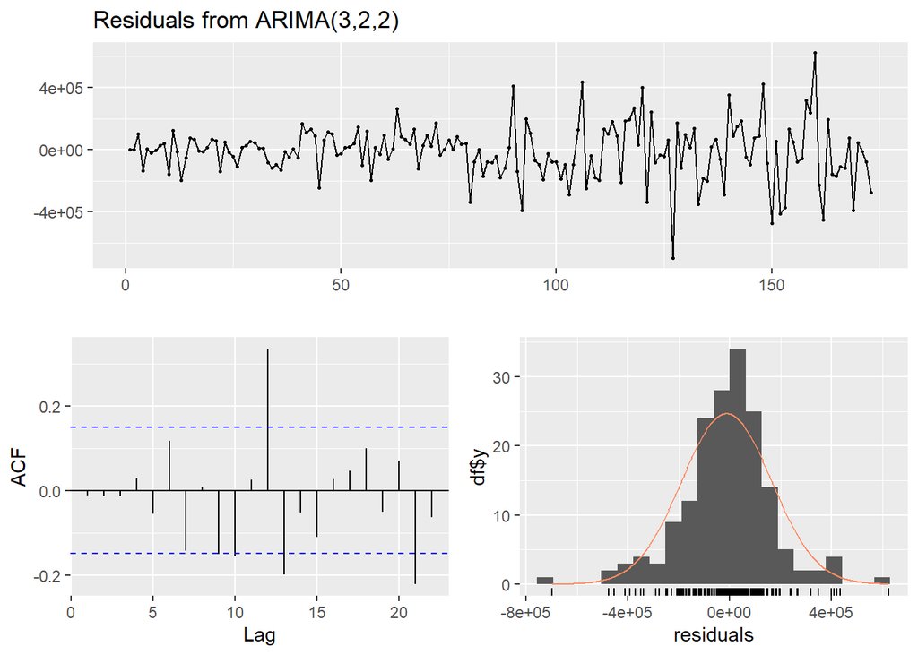

```
##
##  Ljung-Box test
##
## data:  Residuals from ARIMA(3,2,2)
## Q* = 15.73, df = 5, p-value = 0.007659
##
## Model df: 5.   Total lags used: 10
```

```r
checkresiduals(mod_1)
```

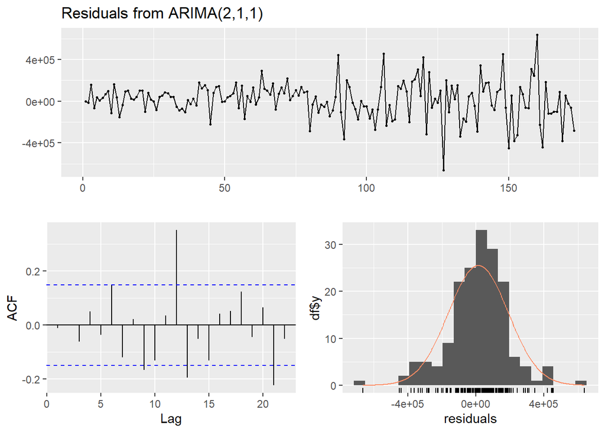

```
##
##  Ljung-Box test
##
## data:  Residuals from ARIMA(2,1,1)
## Q* = 16.368, df = 7, p-value = 0.02196
##
## Model df: 3.   Total lags used: 10
```

```r
checkresiduals(mod_2)
```

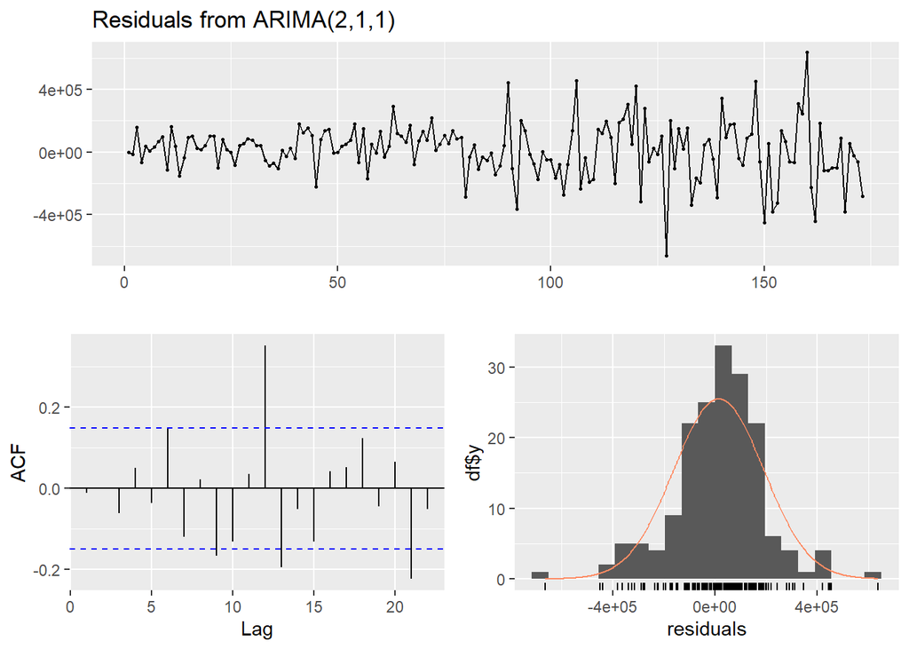

```
##
##  Ljung-Box test
##
## data:  Residuals from ARIMA(2,1,1)
## Q* = 16.368, df = 7, p-value = 0.02196
##
## Model df: 3.   Total lags used: 10
```

```r
checkresiduals(mod_3)
```

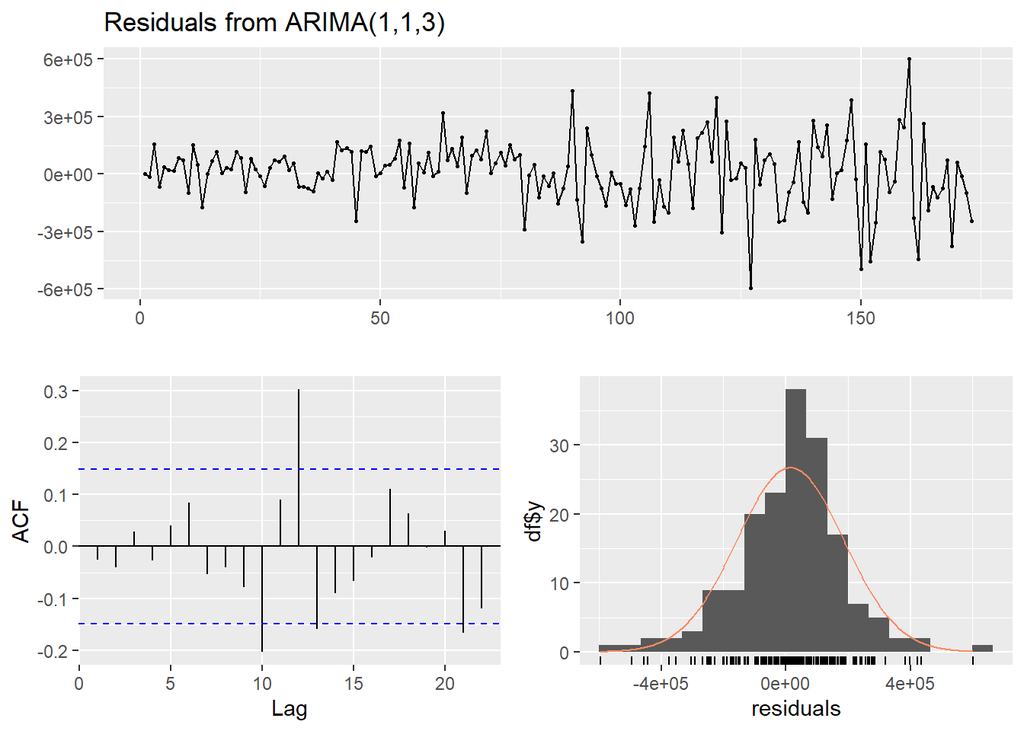

```
##
##  Ljung-Box test
##
## data:  Residuals from ARIMA(1,1,3)
## Q* = 11.905, df = 6, p-value = 0.06412
##
## Model df: 4.   Total lags used: 10
```

```r
checkresiduals(mod_auto)
```

# jurnal 7

berikut kodenya

```r
# Mendapatkan data adri mode residuals
# menggunakan library nortest
library(nortest)
residuals_mod_1 <- residuals(mod_1)

# Uji Kolmogorov-Smirnov
ks_test_result <- ks.test(residuals_mod_1, "pnorm")
print(ks_test_result)
```

```
##
##  Asymptotic one-sample Kolmogorov-Smirnov test
##
## data:  residuals_mod_1
## D = 0.50289, p-value < 2.2e-16
## alternative hypothesis: two-sided
```

```r
# Uji Anderson-Darling
ad_test_result <- ad.test(residuals_mod_1)
print(ad_test_result)
```

```
##
##  Anderson-Darling normality test
##
## data:  residuals_mod_1
## A = 1.7496, p-value = 0.0001697
```

```r
# Uji Cramer von Mises
cv_test_result <- cvm.test(residuals_mod_1)
print(cv_test_result)
```

```
##
##  Cramer-von Mises normality test
##
## data:  residuals_mod_1
## W = 0.28796, p-value = 0.0004494
```

```r
# Uji Shapiro-Wilk
shapiro_test_result <- shapiro.test(residuals_mod_1)
print(shapiro_test_result)
```

```
##
##  Shapiro-Wilk normality test
##
## data:  residuals_mod_1
## W = 0.96666, p-value = 0.0003666
```

berdasarkan hasil pengujian di atas dapt disimpulkan data residual tidak berdistribusi secara normal dengan beberapa hasil uji tersebut

#forecasting model 1

```r
library(forecast)
validation <- forecast(tpriok_train, model = mod_1, h = length(tpriok_test))
actual <- as.vector(tpriok_test)
ape_validation <- abs((as.vector(validation$mean) - actual)/actual)
mape_validation <- mean(ape_validation)
mape_validation
```

```
## [1] 0.3322823
```

#forecasting model 2

```r
library(forecast)
validation <- forecast(tpriok_train, model = mod_2, h = length(tpriok_test))
actual <- as.vector(tpriok_test)
ape_validation <- abs((as.vector(validation$mean) - actual)/actual)
mape_validation <- mean(ape_validation)
mape_validation
```

```
## [1] 0.3346699
```

#forecasting model 3

```r
library(forecast)
validation <- forecast(tpriok_train, model = mod_3, h = length(tpriok_test))
actual <- as.vector(tpriok_test)
ape_validation <- abs((as.vector(validation$mean) - actual)/actual)
mape_validation <- mean(ape_validation)
mape_validation
```

```
## [1] 0.3346699
```

#forecasting model auto

```r
library(forecast)
validation <- forecast(tpriok_train, model = mod_auto, h = length(tpriok_test))
actual <- as.vector(tpriok_test)
ape_validation <- abs((as.vector(validation$mean) - actual)/actual)
mape_validation <- mean(ape_validation)
mape_validation
```

```
## [1] 0.3380016
```

```r
fc <- forecast(tpriok, model = mod_2, h = 5)
summary(fc)
```

```
##
## Forecast method: ARIMA(2,1,1)
##
## Model Information:
## Series: object
## ARIMA(2,1,1)
##
## Coefficients:
##          ar1      ar2     ma1
##       0.2051  -0.0309  -0.806
## s.e.  0.0000   0.0000   0.000
##
## sigma^2 = 3.132e+10:  log likelihood = -2322.87
## AIC=4647.73   AICc=4647.75   BIC=4650.88
##
## Error measures:
##                    ME     RMSE      MAE        MPE     MAPE      MASE
## Training set 14117.58 176474.9 130453.8 -0.6726595 13.96686 0.8897684
##                     ACF1
## Training set -0.01159126
##
## Forecasts:
##     Point Forecast    Lo 80   Hi 80    Lo 95   Hi 95
## 174       956490.3 729672.0 1183308 609601.7 1303379
## 175      1000697.6 756474.5 1244921 627190.6 1374204
## 176      1004230.3 753764.2 1254696 621175.5 1387285
## 177      1003587.7 747655.1 1259520 612172.5 1395003
## 178      1003346.6 741965.8 1264727 603599.2 1403094
```

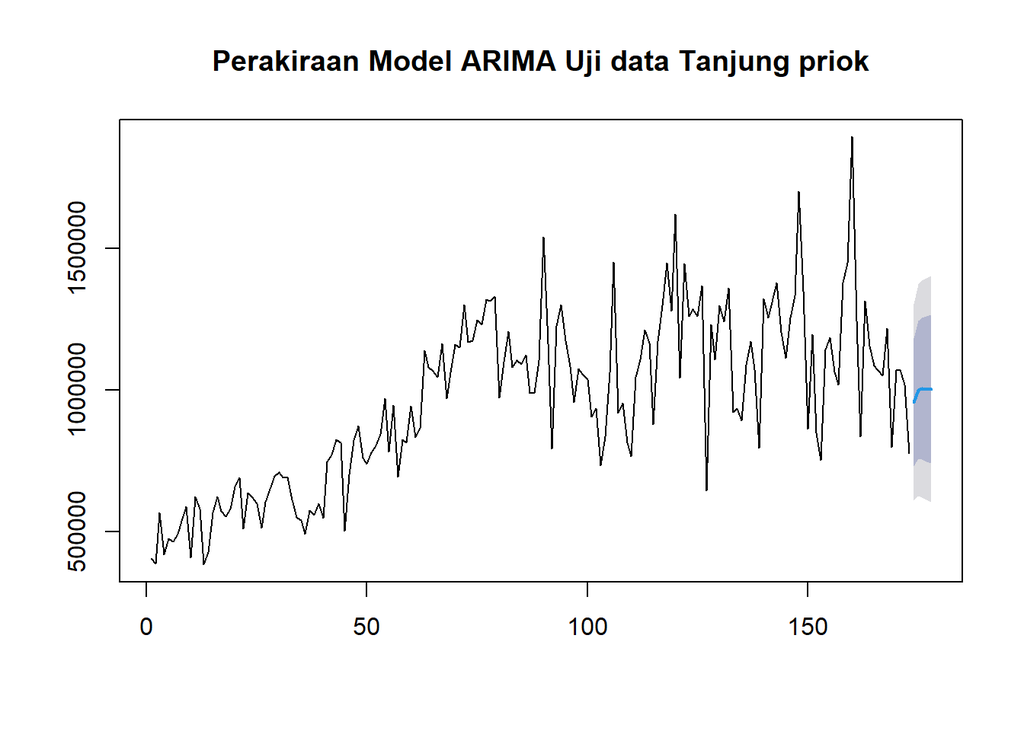

```r
plot(fc, main = "Perakiraan Model ARIMA Uji data Tanjung priok")
```

# Jurnal 8 dengan melakukan uji yang sama

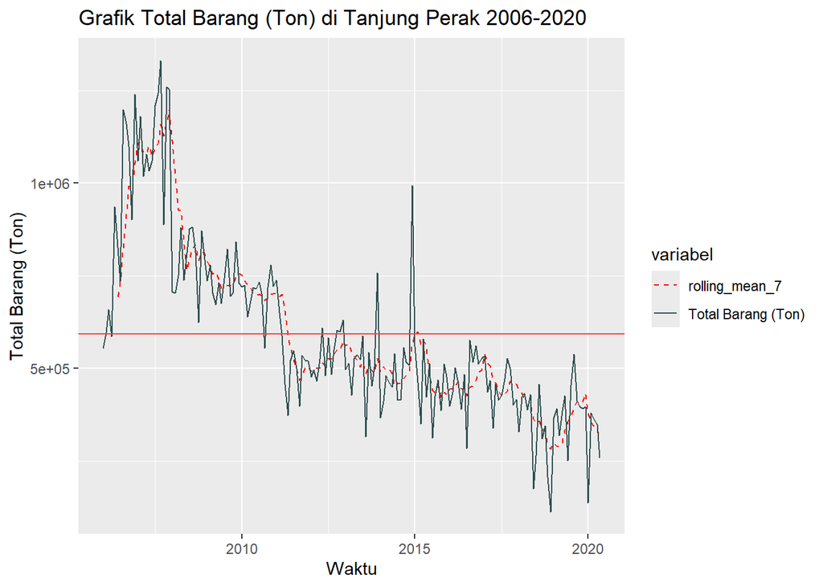

```r
# Memanggil Data
data <- read_excel("Data1.xlsx", sheet = "Tanjung Perak", col_types = c("date", "numeric"))

# Menghitung rolling mean 7 hari
data <- data %>%
  mutate(rolling_mean_7 = rollmean(`Total Barang (Ton)`, k = 6.5, fill = NA, align = "right"))

# Mengelompokkan data
df <- data %>%
  select(Waktu, `Total Barang (Ton)`, rolling_mean_7) %>%
  gather(key = "variabel", value = "value", -Waktu)

# Membuat grafik data
ggplot(df, aes(x = Waktu, y = value, group = variabel)) +
  geom_line(aes(linetype = variabel, color = variabel)) +
  geom_hline(yintercept = mean(data$`Total Barang (Ton)`), color = "brown1") +
  scale_linetype_manual(values = c("dashed", "solid", "dashed")) +
  scale_color_manual(values = c("red", "darkslategrey")) +
  labs(title = "Grafik Total Barang (Ton) di Tanjung Perak 2006-2020", x = "Waktu", y = "Total Barang (Ton)")
```

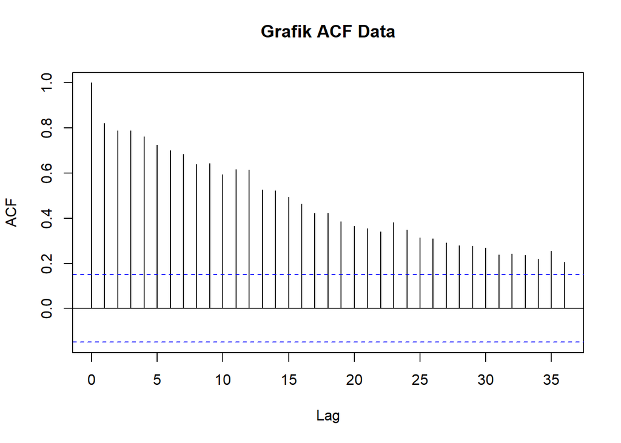

```r
acf(data$`Total Barang (Ton)`, main = "Grafik ACF Data", lag.max = 36)
```

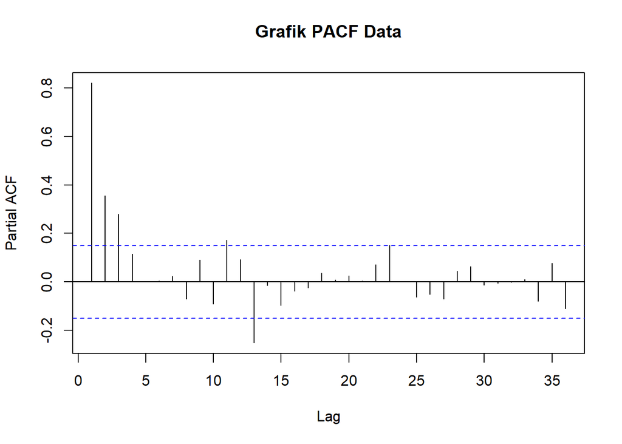

```r
pacf(data$`Total Barang (Ton)`, main = "Grafik PACF Data", lag.max = 36)
```

```r
# Membuat data train dan validation dan mengubahnya menjadi data
# time series
# Ini dibutuhkan untuk menghasilkan data prediksi
tpriok <- ts(data$`Total Barang (Ton)`)
# data yang akan digunakan untuk membuat model
tperak_train <- ts(data$`Total Barang (Ton)`[1:138])
# data yang akan digunakan untuk memvalidasi model
tperak_tes <- ts(data$`Total Barang (Ton)`[139:173])
```

```r
y_mean <- mean(tperak_train)
rmse_train <- mean((tperak_train - y_mean)^2)^0.5
rmse_train
```

```
## [1] 231627.3
```

```r
y_mean <- mean(tperak_train)
mape_train <- mean(abs((tperak_train - y_mean))/tperak_train)
mape_train
```

```
## [1] 0.3011202
```

```r
# Menghitung uji adf tperak_train
uji_adf <- adf.test(tperak_train)

# informasi uji adf
cat("\nDickey-Fuller =", uji_adf$statistic, ", p-value =", uji_adf$p.value, "\nalternative hypothesis: stationary\n")
```

```
##
## Dickey-Fuller = -3.28465 , p-value = 0.07673617
## alternative hypothesis: stationary
```

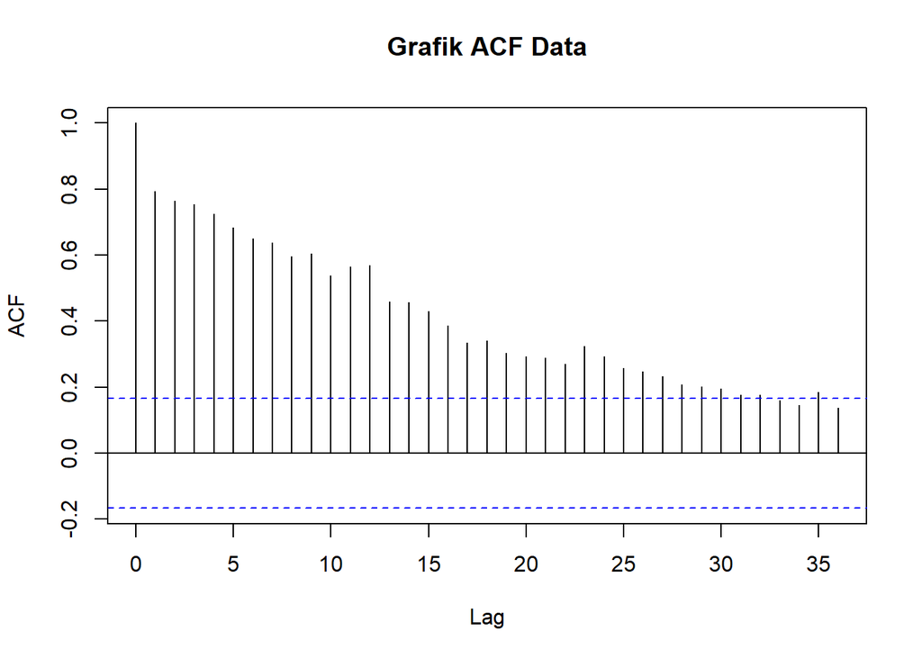

```r
# Plot ACF data dengan lag maksimum 36
acf(tperak_train, main = "Grafik ACF Data", lag.max = 36, cex.main = 1.5)
```

```r
tperak_train_diff <- diff(tperak_train)
#uji adf tperak_train_diff

uji_adf_dif <- adf.test(tperak_train_diff)
```

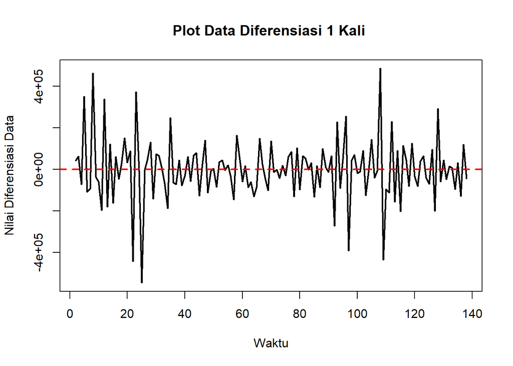

```r
plot(tperak_train_diff, lwd = 2, main = "Plot Data Diferensiasi 1 Kali ",

xlab = "Waktu", ylab = "Nilai Diferensiasi Data")
abline(h = mean(tperak_train_diff), lwd = 2, lty = 2, col = "red")
```

```r
cat("\nDickey-Fuller =", uji_adf_dif$statistic, ", p-value =", uji_adf_dif$p.value, "\nalternative hypothesis: stationary\n")
```

```
##
## Dickey-Fuller = -5.757726 , p-value = 0.01
## alternative hypothesis: stationary
```

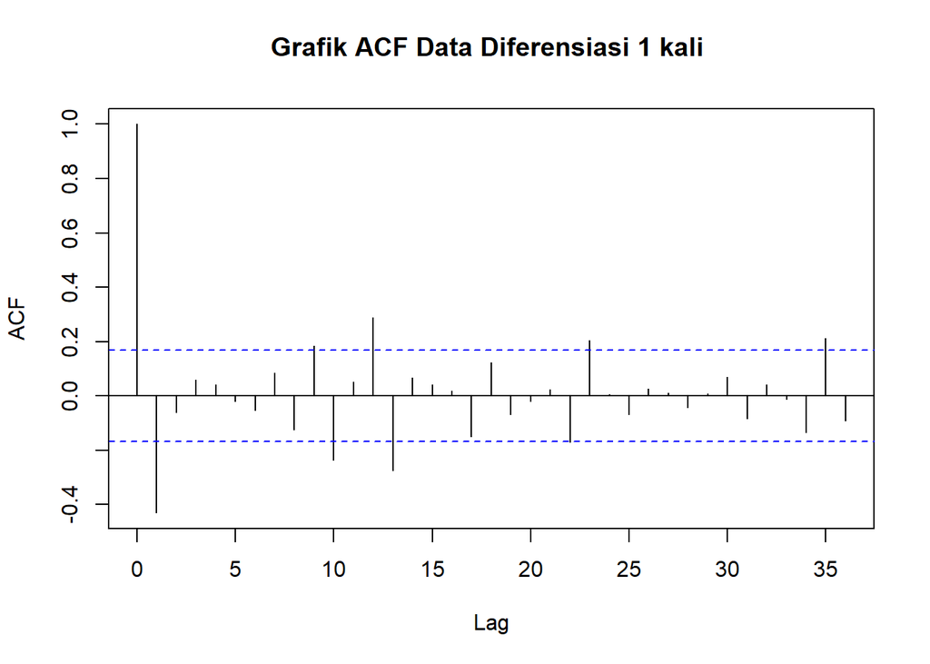

```r
acf(tperak_train_diff, main = "Grafik ACF Data Diferensiasi 1 kali ", lag.max = 36)
```

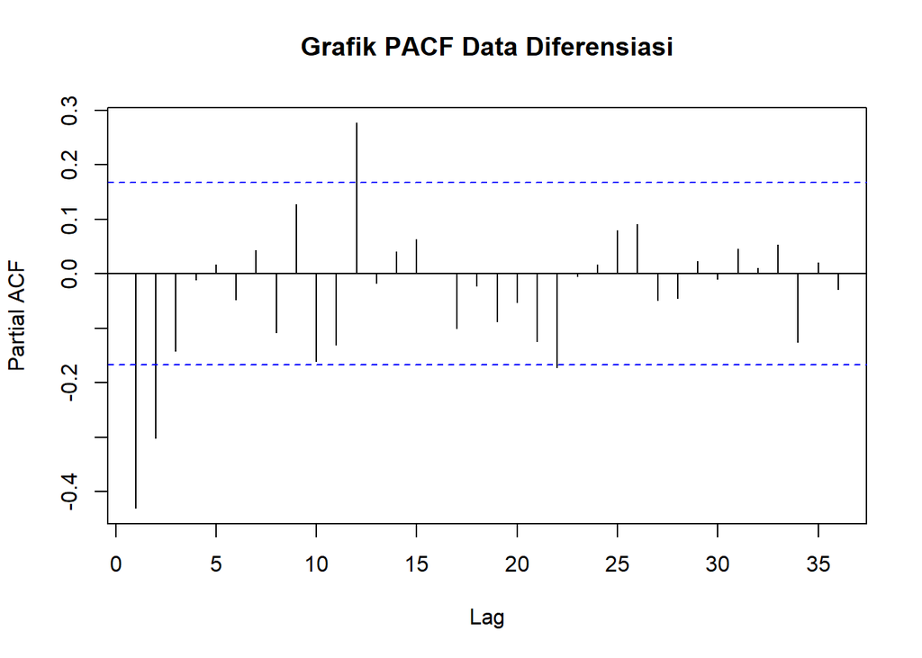

```r
pacf(tperak_train_diff, main = "Grafik PACF Data Diferensiasi", lag.max = 36)
```